# Does Temperature Affect Frogspawn Development?

Nicole Ajibade

2023-03-03

## How does frogspawn hatching time vary with temperature?

We collected newly-layed frogspawn from a pond in the Italian Alps and we brought them back to the lab, where we divided them into 60 water containers. 20 of the containers’ water temperature was kept to 13°C, 20 containers were kept to 18°C and the remaining 20 containers were kept to 25°C. Having a high number of replicates increases our confidence that the expected difference between groups is due to the factor we are interested in. Here, temperature.

We monitored each water container and we recorded hatching times (days until hatching of eggs) in a spreadsheet (here called frogs_messy_data.csv).

Our response variable is Hatching_time.

Our explanatory variable is Temperature, with 3 levels: 13°C, 18°C and 25°C.

```
##  Frogspawn sample id Temperature13  Temperature18 Temperature25
##  Min.   : 1.00       Min.   :24.0   Min.   :19    Min.   :14.0
##  1st Qu.:15.75       1st Qu.:26.0   1st Qu.:20    1st Qu.:15.0
##  Median :30.50       Median :26.5   Median :21    Median :16.5
##  Mean   :30.50       Mean   :26.3   Mean   :21    Mean   :16.2
##  3rd Qu.:45.25       3rd Qu.:27.0   3rd Qu.:22    3rd Qu.:17.0
##  Max.   :60.00       Max.   :28.0   Max.   :23    Max.   :18.0
##                      NA's   :40     NA's   :40    NA's   :40
```

Hypothesis - the mean frogspawn hatching time will vary with temperature level. We can predict that given our temperature range, at the highest temperature (25°C) hatching time will be reduced.

```
##   frogspawn_id   temperature             days
##  Min.   : 1.00   Length:60          Min.   :14.00
##  1st Qu.:15.75   Class :character   1st Qu.:17.00
##  Median :30.50   Mode  :character   Median :21.00
##  Mean   :30.50                      Mean   :21.17
##  3rd Qu.:45.25                      3rd Qu.:26.00
##  Max.   :60.00                      Max.   :28.00
```

```
## # A tibble: 3 × 7
##   term          estimate std.error statistic  p.value conf.low conf.high
##   <chr>            <dbl>     <dbl>     <dbl>    <dbl>    <dbl>     <dbl>
## 1 (Intercept)       26.3     0.257     102.  2.78e-66    25.8      26.8
## 2 temperature18     -5.3     0.364     -14.6 7.08e-21    -6.03     -4.57
## 3 temperature25    -10.1     0.364     -27.8 8.19e-35   -10.8      -9.37
```

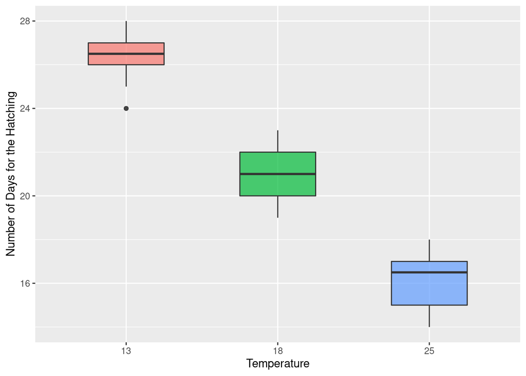

```r
ggplot(data = frogs, aes(x = temperature, y = days)) +
  geom_boxplot(aes(fill = temperature),
              alpha = 0.7,
              width = 0.5, # change width of boxplot
              show.legend = FALSE)+
   labs(x = "Temperature",
       y = "Number of Days for the Hatching")
```

### Summary

Increasing temperatures had a clear effect on reducing the time taken for frogspawn to hatch (one-way ANOVA: F2,57 = 385.9, P < 0.001). At 13 ∘ C the mean time to hatching was 26.3 days [25.8-26.8 95% CI], this reduced by an average of 5.3 days [4.57 - 6.02] at 18 ∘ C and by 10.1 days [9.37 - 10.82] at 25 ∘ C.